# Chapter 5: Time Value of Money

FINA 3000 · Business Finance I · Class 6

Dr. Justin Mohr

September 10, 2026

## Compounding

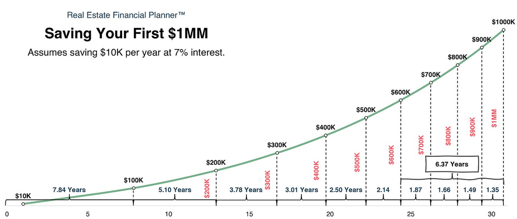

## Retirement

You plan to retire in 40 years. You have decided you will need $1,000,000. The nominal interest rate is 7%.

How much do you need to save every month if you start at the end of this month?

N40*12I/Y7/12PV0PMT?FV1,000,000

CPT PMT-380.98

## Retirement, ten years later

Same goal, same 7% nominal interest rate, but you put it off.

How much do you need to save every month if you start 10 years from now, at the end of that month?

N30*12I/Y7/12PV0PMT?FV1,000,000

CPT PMT-819.69

## Why the difference?

Waiting ten years takes the monthly saving from **$380.98** to **$819.69**.

You save for 10 fewer years and it costs you more than **twice** as much every month.

Why the difference?

Compound interest.

The first ten years of deposits are the ones with the longest to grow, so they are the ones doing the most work. Delaying does not remove ten years of saving: it removes the ten most valuable years.

## Importance of compounding

You are offered two 5 year CDs to invest $1K in. They both offer 8% interest, but one compounds monthly and the other compounds yearly. What is the expected value of each at 5 years?

**Option 1**

N5*12I/Y8/12PV-1KPMT0FV?

CPT FV1,489.85

**Option 2**

N5I/Y8PV-1KPMT0FV?

CPT FV1,469.33

## Nominal vs Effective Interest

- Nominal: Quoted rate, APR. Not what you actually pay
  - Compounding matters!
- Effective: The equivalent rate if you only compounded interest once

Balance on a $100 deposit at an 8% nominal rate: interest paid once at the end of month 12 against interest compounded monthly at 8%/12 every period.

| Month | 0 | 1 | 2 | 3 | 4 | 5 | 6 | 7 | 8 | 9 | 10 | 11 | 12 |
| --- | --- | --- | --- | --- | --- | --- | --- | --- | --- | --- | --- | --- | --- |
| Annual | $100 | $100 | $100 | $100 | $100 | $100 | $100 | $100 | $100 | $100 | $100 | $100 | $108 |
| Monthly, 8%/12 each period | $100.00 | $100.67 | $101.34 | $102.01 | $102.69 | $103.38 | $104.07 | $104.76 | $105.46 | $106.16 | $106.87 | $107.58 | $108.30 |

Nominal: 8%

$$EAR=\left(1+\frac{APR}{M}\right)^{M}-1$$

EAR:

8.3%

## Using Calculator

- The EAR(EFF) to APR thing is on the calculator!
  - 2nd ICONV
  - 2nd Clear
  - Fields
    - NOM-(Nominal or APR)
    - EFF (Effective or EAR)
    - C/Y (Compounding periods or M)

## Using Calculator

- Let’s solve the last problem
  - APR 8%
  - Compounded Monthly
  - EFF?

8.3%, with **C/Y = 12**.

What would C/Y be with daily compounding?

**365.**

## Importance of compounding

Two 5 year CDs, $1,000 in each.

One compounds **monthly at 8%**. The other compounds **yearly at 8.3%**, the effective rate we just computed. What is each worth at 5 years?

**Option 1**

N5*12I/Y8/12PV-1,000PMT0FV?

CPT FV1,489.85

**Option 2**

N5I/Y8.3PV-1,000PMT0FV?

CPT FV1,489.85

**$1,489.85 either way.**

## Annuity

Starting at the end of this month, you will invest 100 dollars into an account with an annual interest rate of 3%. Interest compounds monthly. How much will you have in 10 years?

N10*12I/Y3/12PV0PMT-100FV?

CPT FV13,974.14

## Ordinary Annuity vs. Annuity Due

Ordinary Annuity

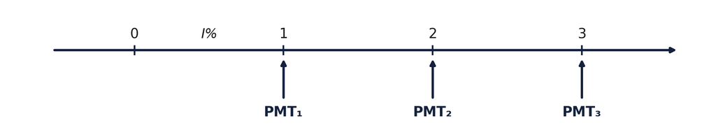

Annuity Due

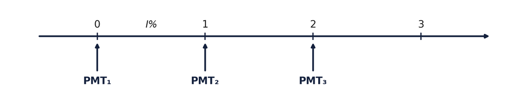

## Annuity Due

Suppose that you are planning to send your daughter to college in 18 years. Furthermore, assume that you have determined that you will need $100,000 at that time in order to pay for tuition, room and board, party supplies, etc. If you believe that you can earn an average annual rate of return of 8% per year, how much money would you need to invest at the beginning of each year (starting today) to achieve your goal?

BGN

N18I/Y8%PV0PMT?FV100,000

CPT PMT-2472.42

## Betting on Grandma

You want to buy a $140K house, but banks will not lend to you even with your $14K down payment. Your relator convinces the seller to take a 126K mortgage at a rate of 5% provided it is paid back in 3 years.

You expect to inherit 140K in 3 years. The most you can pay is $22K a year without the inheritance. Assume annual payments.

If the loan was amortized over 3 years,

what would the payment be?

N3I/Y5PV126KPMT?FV0

CPT PMT-46.3K

## Betting on Grandma

You want to buy a $140K house, but banks will not lend to you even with your $14K down payment. Your relator convinces the seller to take a 126K mortgage at a rate of 5% provided it is paid back in 3 years.

You expect to inherit 140K in 3 years. The most you can pay is $22K a year without the inheritance. Assume annual payments.

If the loan was amortized over 30 years,

what would the payment be?

N30I/Y5PV126KPMT?FV0

CPT PMT-8,196

## Ballon Payment

- Very common prior to GFC
- Large one-time sum due at the end of a loan term, following smaller periodic payments that typically cover primarily or exclusively interest costs.
- Balloon payments present both opportunities and risks; they offer lower initial costs but can lead to financial difficulty if property values fall or refinancing options are unavailable.

## Betting on Grandma

You want to buy a $140K house, but banks will not lend to you even with your $14K down payment. Your relator convinces the seller to take a 126K mortgage at a rate of 5% provided it is paid back in 3 years.

You expect to inherit 140K in 3 years. The most you can pay is $22K a year without the inheritance. Assume annual payments.

Seller agrees to let you make the 30 yr

payment, but the loan must be paid in full

at 3 years. What is the Balloon Payment?

N3I/Y5PV126KPMT-8,196FV?

CPT FV-120K

Balloon Payment

~120K+8,196K

## The Rule of 72

Luca **Pacioli**, *Summa de arithmetica* (Venice, 1494; this is the 1523 second edition).

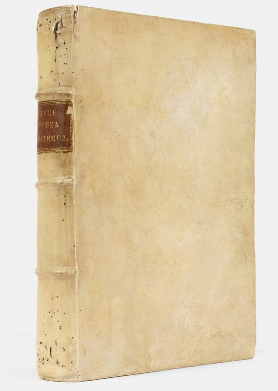

[figure not shown]

[figure not shown]

[figure not shown]

[figure not shown]

[figure not shown]

[figure not shown]

1 / 7

Luca Pacioli, *Summa de arithmetica*, second edition. Toscolano: Paganino Paganini, 1523.  
Photographs and copy offered by [Shapero Rare Books](https://shapero.com/en-us/products/luca-pacioli-summa-arithmetica-second-edition-105576), London, at **$186,266**.

## In Pacioli’s words

A voler sapere ogni quantità a tanto per 100 l’anno, in quanti anni sarà tornata doppia tra utile e capitale, tieni per regola **72**, a mente, il quale sempre partirai per l’interesse, e quello che ne viene, in tanti anni sarà raddoppiato. Esempio: Quando l’interesse è a 6 per 100 l’anno, dico che si parta **72** per 6; ne vien 12, e in 12 anni sarà raddoppiato il capitale.

In wanting to know of any capital, at a given yearly percentage, in how many years it will double adding the interest to the capital, keep as a rule the number **72** in mind, which you will always divide by the interest, and what results, in that many years it will be doubled. Example: When the interest is 6 percent per year, I say that one divides **72** by 6; 12 results, and in 12 years the capital will be doubled.

## Does it work?

How long does $5,000 take to double at 8%? Use the rule first.

72 / 8 = **9 years**.

Now check it.

N?I/Y8PV-5,000PMT0FV10,000

CPT N9.01

The rule works best between **6% and 10%**.

Years to double: the rule against the exact answer

| rate | 72 / r | exact | off by |
| --- | --- | --- | --- |
| 4% | 18.00 | 17.67 | +0.33 |
| 6% | 12.00 | 11.90 | +0.10 |
| 8% | 9.00 | 9.01 | -0.01 |
| 10% | 7.20 | 7.27 | -0.07 |
| 20% | 3.60 | 3.80 | -0.20 |

## Practice: Your Goals

Six years from today you will need $10K

You plan to save 1,500 annually starting a year from today at 5%

What will your last (year 6) payment be?

N6I/Y5%PV0PMT-1,500FV?

CPT FV10,202.87

Last PMT?

1,500-202.87

Practice: Find the balance at the end of year 6, calculate how much interest that earns will earn over the next year. How short of 10K are you? Is the answer the same?

## Practice: Uneven CF

James needs 4K one year from today

The bank offers 6% nominal interest compounded quarterly.

James will only make 2 even payments in Q1 and Q2?

What are these payments?

Step one

N2I/Y6%/4PV?PMT0FV4K

CPT PV-3,882.64

Step two

N2I/Y6%/4PV0PMT?FV3,882.64

CPT PMT-1,926.87

## Practice: Annuity

Liza will have $1,500,000 in her Roth IRA when she turns 65.

Once Liza turns 65, she wants to make equal withdrawals from her IRA as soon as she turns 65.

The IRA has an expected return of 8.4% APR compounded monthly.

How large will Lisa’s monthly withdrawals be if she wishes to make these withdrawals for 25 years?

BGN

N25*12I/Y8.4/12PV-1.5MPMT?FV0

CPT PMT11,894

What type of annuity?

Due

## Practice: Goals

Velma and Daphne are each 25 and they win $10,000 each. They decide to contribute each year 5,000 for every year after.

Velma invests in bonds at 8%. Daphne invests in a Bio-tech fund at 13%. How old will each be when they are millionaires.

Daphne

N?I/Y13%PV-10,000PMT-5,000FV1M

CPT N25.08

How old?

50.08

Velma

N?I/Y8%PV-10,000PMT-5,000FV1M

CPT N34.89

How old?

59.89

## Practice: Goals

How much would Velma have to invest to retire at the same age as Daphne?

N25.08I/Y8%PV-10,000PMT?FV1M

CPT PMT-12,644.76

Is it rational or irrational for Daphne to invest in bonds?

## Practice: FV of an annuity

- Jesse has started working for Mr. White and wants to save for retirement. He is 26.
- If he invests $8000 per year into the market earning 10%
  - How much money will he have at 65?

N65-26I/Y10PV0PMT-8,000FV?

CPT FV3.211M

## Practice: FV of an annuity

- Jesse expects to live to 85 and retire at 65
  - If he retires at 65, how much can he withdraw per year?

N85-65I/Y10PVSEE BEFOREPMT?FV0

CPT PMT~377K

## Upcoming Dates

Upcoming class dates and deadlines

| Date | Topic | Due / Notes |
| --- | --- | --- |
| Sun Sep 13 | MindTap Ch 5 | HW DUE |
| Tue Sep 15 | Review for Test 1 | Review |
| Thu Sep 17 | Test 1 | EXAM |
| Tue Sep 22 | Chapter 7: Bonds | - |

**Office:** 325 Holman Hall · **Office hours:** T TH 10:50A-12:20P · jjmohr1@olemiss.edu